# Graphiques Premiers Résultats

Documentation de la fonction pour les graphiques en barre

Auteur·rice

Arno Muller

# Introduction

## Informations générales

→ **Objectifs :** Faire des graphiques, les plus uniformes possibles pour la “collection” des 1er Résultats des Enquêtes Ined.

→ **Graphiques possibles :**

- Bâtons côte-à-côte.
- Barres empilées.
- Courbes

→ **Où trouver les fonctions :** Elles sont hébergées dans les espaces partagés des groupes d’exploitations.

## Utilisation des fonctions

1. Importer ou créer des données à afficher dans le graphique (voir plus bas pour les exemple, ou les fichiers Excel d’exemples dans le dossier /Data).
2. Importer la fonction dans R avec une fonction `source()` (c’est l’équivalent d’un `library()`)
3. Créer le graphique voulu

**AvertissementAttention :**

Il n’est plus nécessaire d’utiliser la fonction `ined_export()`, les fonctions de création de graphiques proposent désormais une option pour enregistrer directement les graphiques au format .pdf et .svg (voir plus bas), et elles affichent dans Rstudio la “vraie” version du graphique.

4. Cliquer-glisser l’image .svg dans la fiche

**AstuceAstuces 1 :**

Vous pouvez modifier les données pour changer le graphique. En-bas de fiches : des solutions faciles pour recoder des modalités, et changer les ordres.

**AstuceAstuces 2 :**

Pour les personnes qui maitrisent ggplot2, les fonctions créée un objet, nommé `graph`, que vous pouvez modifier, en ajoutant les lignes de codes de ggplot2 voulues. Dans ce cas, la fonction `ined_export()` peut être utile pour sortir votre graphique modifié dans les bonnes dimensions.

# Graphiques en barres

## Fonction ined_baton()

### Données & Variables

- **donnees** : (obligatoire) Données à utiliser dans le graphique. Il s’agit de données agrégées dans le même format que les données de la section “Exemple”, ci-dessous.

Pour tous les arguments ci-dessous, il est possible d’indiquer soit le nom (entre guillemets), soit la position (numéro de colonne) des variables.

- **var_y** : (obligatoire) Variable numérique des valeurs. Il s’agit des quantités à représenter sur le graphique.
- **var_x** : (obligatoire) Variable à afficher sur l’axe X.
- **var_couleur** : Variable catégorielle qui détermine la couleur des barres.
- **var_facet** : Variable catégorielle qui crée des graphiques côte-à-côte pour chaque modalité d’une variable.

### Ordre des modalités et couleurs

- **facet_disposition** : position des graphiques en facettes (avec l’argument : *var_facet*), sur des lignes, sur des colonnes, ou en carré/mosaïque.
  - *“colonne* : En colonne, l’un à côté de l’autre.
  - *“ligne”* : En ligne, l’un au dessus de l’autre.
  - *“carre”* : Disposition automatique, en carré.
- **var_x_ordre** : Ordre des modalités de la variable X.
  - *“base”* : Ordre présent dans les données renseignées dans *donnees*.
  - *“inverse”* : Inverse de l’ordre de la base.
  - *“alpha”* : Ordre alphabétique.
  - *“croissant”* : Modalités ordonnées dans l’ordre croissant des effectifs de chaque modalité de *var_x*.
- **var_couleur_ordre** : Ordre des modalités de la variable de couleurs, créée avec *var_couleur* (dans la légende et dans l’ordre des barres).
  - *“base”* : Ordre présent dans les données renseignées dans *donnees*.
  - *“inverse”* : Inverse de l’ordre de la base.
  - *“alpha”* : Ordre alphabétique.
- **palette** : Choix de la palette de couleurs
  - *“categorie”* : (défaut) Une palette avec 9 couleurs pour des variables catégorielles, sans hiérarchie.
  - *“genre”* : Une palette avec 4 couleurs à utiliser pour visualiser les variables de genre
  - *“orange”* : Une palette avec un dégradé de 7 orange pour les variables ordinales
  - *“violet”* : Une palette avec un dégradé de 7 violet pour les variables ordinales
  - *“oppose”* : Une palette qui va du violet au orange, et qui s’adapte au nombre de modalité (jusqu’à 8)

**NoteInverser la palette**

Toutes les palettes peuvent être inversées en ajoutant le suffixe “_inv”, par exemple : “oppose_inv” ou “categorie_inv”.

### Etiquettes

- **etiquette** : Afficher une étiquette de valeur sur les barres.
  - *“oui”* : Affiche toutes les étiquettes
  - *“max”* : Affiche uniquement la valeur maximale
  - *“non”* : Pas d’étiquettes
- **etiquette_min** : Valeur numérique minimale à partir de laquelle afficher les étiquettes.
- **etiquette_arrondi** : Nombre de chiffre après la virgule pour les étiquettes.

### Légende

- **legende_position** : Position de la légende.
  - *A droite* : “right”, “droite”
  - *En bas* : “bottom”, “bas”
  - *A gauche* : “left”, “gauche”
  - *En haut* : “top”, “haut”
  - *Dans le graphique* : coordonnées de la position sur le graphique.  
    → Exemple : c(0.75, 0.33), pour placer le coin supérieur gauche de la légende en X = 0.75 et Y = 0.33
- **legende_ncol** : Nombre de colonnes sur lesquelles la légende est répartie.
- **legende_ordre** : “ligne” ou “colonne” ; Si la légende est disposée sur plusieurs colonnes, permet de changer l’ordre de lecture des modalités, pour les placer en ligne ou en colonne.

### Modification axes X et Y

**Axe Y :**

- **y_min** : Valeur minimale à afficher de l’axe Y
- **y_max** : Valeur maximale à afficher de l’axe Y
- **y_intervalle** : Intervalle entre les graduations de l’axe Y
- **y_pct** : TRUE / FALSE ; Si TRUE : l’échelle de l’axe Y affiche le symbole “%”

**Axe X :** - **var_x_angle** : Angle des modalités de l’axe X.

### Textes & Titres

**Titres :**

- **titre** : Titre du graphique (entre guillemets)
- **titre_x** : Titre de l’axe X (entre guillemets)
- **titre_y** : Titre de l’axe Y (entre guillemets)
- **titre_legende** : Titre de la légende (entre guillemets)

**Nombre de caractères avant un saut de ligne :**

Si besoin en cas de textes trop longs.

- **ncarac_titre** : Pour le titre
- **ncarac_titre_x** : Pour le titre de l’axe X
- **ncarac_titre_y** : Pour le titre de l’axe Y
- **ncarac_titre_legende** : Pour le titre de la légende
- **ncarac_var_x** : Pour les modalités de l’axe X
- **ncarac_legende** : Pour les modalités de la légende
- **ncarac_facet** : Pour les modalités des facettes.

### Export

- **export** : TRUE ou FALSE ; si TRUE : enregistre l’image aux formats .pdf et .svg, si FALSE : affiche uniquement le graphique
- **fichier** : chemin et nom du fichier à enregistrer, par défaut “graphique”.
- **format** : “petit”, “moyen”, “grand”, définit le format du graphique.

## Exemple

### Charger la fonction

```r
source("Programme/fonction_baton.R")
# ou depuis GitHub (dernière version)
source("https://raw.githubusercontent.com/arnomuller/Fonction_R/refs/heads/main/inedits/Programme/fonction_baton.R")
```

## Fonctionnement

```r
library(openxlsx)
dt_barre = read.xlsx("Data/data_ex_barre.xlsx", sheet = 1)
```

| Valeur | Modalites |
| --- | --- |
| 34.4 | Etudes, Travail |
| 7.4 | Fête ou soirée |
| 9.3 | Famille ou au domicile |
| 10.3 | Application de rencontres |
| 8.8 | Autres espaces numériques |
| 6.3 | Autre (dont association, vacances, etc.) |
| 23.5 | Lieu public |

```r
library(openxlsx)
dt_barre = read.xlsx("Data/data_ex_barre.xlsx",
                     sheet = 2)
```

| Valeur | Lieu | Modalites |
| --- | --- | --- |
| 8,5 | Etudes, Travail | Même sexe hommes |
| 1,5 | Fête ou soirée | Même sexe hommes |
| 5,9 | Famille ou au domicile | Même sexe hommes |
| 46,7 | Application de rencontres | Même sexe hommes |
| 19,8 | Autres espaces numériques | Même sexe hommes |
| 3,5 | Autre (dont association, vacances, etc.) | Même sexe hommes |
| 14,1 | Lieu public | Même sexe hommes |
| 38,4 | Etudes, Travail | Même sexe femmes |
| 4,3 | Fête ou soirée | Même sexe femmes |
| 3,1 | Famille ou au domicile | Même sexe femmes |
| 24,2 | Application de rencontres | Même sexe femmes |
| 11,7 | Autres espaces numériques | Même sexe femmes |
| 5,4 | Autre (dont association, vacances, etc.) | Même sexe femmes |
| 12,9 | Lieu public | Même sexe femmes |
| 34,4 | Etudes, Travail | Sexe différent |
| 7,4 | Fête ou soirée | Sexe différent |
| 9,3 | Famille ou au domicile | Sexe différent |
| 10,3 | Application de rencontres | Sexe différent |
| 8,8 | Autres espaces numériques | Sexe différent |
| 6,3 | Autre (dont association, vacances, etc.) | Sexe différent |
| 23,5 | Lieu public | Sexe différent |

```r
library(openxlsx)
dt_barre = read.xlsx("Data/data_ex_barre.xlsx",
                     sheet = 3)
```

| Valeur | Lieu | Modalites | Relation |
| --- | --- | --- | --- |
| 8,5 | Etudes, Travail | Même sexe hommes | Couples |
| 1,5 | Fête ou soirée | Même sexe hommes | Couples |
| 5,9 | Famille ou au domicile | Même sexe hommes | Couples |
| 46,7 | Application de rencontres | Même sexe hommes | Couples |
| 19,8 | Autres espaces numériques | Même sexe hommes | Couples |
| 3,5 | Autre (dont association, vacances, etc.) | Même sexe hommes | Couples |
| 14,1 | Lieu public | Même sexe hommes | Couples |
| 38,4 | Etudes, Travail | Même sexe femmes | Couples |
| 4,3 | Fête ou soirée | Même sexe femmes | Couples |
| 3,1 | Famille ou au domicile | Même sexe femmes | Couples |
| 24,2 | Application de rencontres | Même sexe femmes | Couples |
| 11,7 | Autres espaces numériques | Même sexe femmes | Couples |
| 5,4 | Autre (dont association, vacances, etc.) | Même sexe femmes | Couples |
| 12,9 | Lieu public | Même sexe femmes | Couples |
| 34,4 | Etudes, Travail | Sexe différent | Couples |
| 7,4 | Fête ou soirée | Sexe différent | Couples |
| 9,3 | Famille ou au domicile | Sexe différent | Couples |
| 10,3 | Application de rencontres | Sexe différent | Couples |
| 8,8 | Autres espaces numériques | Sexe différent | Couples |
| 6,3 | Autre (dont association, vacances, etc.) | Sexe différent | Couples |
| 23,5 | Lieu public | Sexe différent | Couples |
| 5,1 | Etudes, Travail | Même sexe hommes | Histoire d'un soir |
| 2,4 | Fête ou soirée | Même sexe hommes | Histoire d'un soir |
| 0,7 | Famille ou au domicile | Même sexe hommes | Histoire d'un soir |
| 64,6 | Application de rencontres | Même sexe hommes | Histoire d'un soir |
| 9,0 | Autres espaces numériques | Même sexe hommes | Histoire d'un soir |
| 7,0 | Autre (dont association, vacances, etc.) | Même sexe hommes | Histoire d'un soir |
| 11,2 | Lieu public | Même sexe hommes | Histoire d'un soir |
| 38,8 | Etudes, Travail | Même sexe femmes | Histoire d'un soir |
| 6,5 | Fête ou soirée | Même sexe femmes | Histoire d'un soir |
| 2,1 | Famille ou au domicile | Même sexe femmes | Histoire d'un soir |
| 14,9 | Application de rencontres | Même sexe femmes | Histoire d'un soir |
| 2,3 | Autres espaces numériques | Même sexe femmes | Histoire d'un soir |
| 16,3 | Autre (dont association, vacances, etc.) | Même sexe femmes | Histoire d'un soir |
| 19,1 | Lieu public | Même sexe femmes | Histoire d'un soir |
| 24,0 | Etudes, Travail | Sexe différent | Histoire d'un soir |
| 9,1 | Fête ou soirée | Sexe différent | Histoire d'un soir |
| 8,5 | Famille ou au domicile | Sexe différent | Histoire d'un soir |
| 16,1 | Application de rencontres | Sexe différent | Histoire d'un soir |
| 6,7 | Autres espaces numériques | Sexe différent | Histoire d'un soir |
| 7,8 | Autre (dont association, vacances, etc.) | Sexe différent | Histoire d'un soir |
| 27,8 | Lieu public | Sexe différent | Histoire d'un soir |

**Une variable**

```r
ined_baton(
    donnees = dt_barre,
    var_y = "Valeur",
    var_x = "Modalites",
    etiquette = "oui",
    etiquette_arrondi = 2,
    var_x_ordre = "croissant",
    y_min = 0,
    y_max = 40,
    y_intervalle = 5,
    y_pct = TRUE,
    var_x_angle = 45,
    ncarac_var_x = 20,

    #Export
    export  = TRUE,
    fichier = "Sortie/barre_petit",
    format = "petit"

    )
```

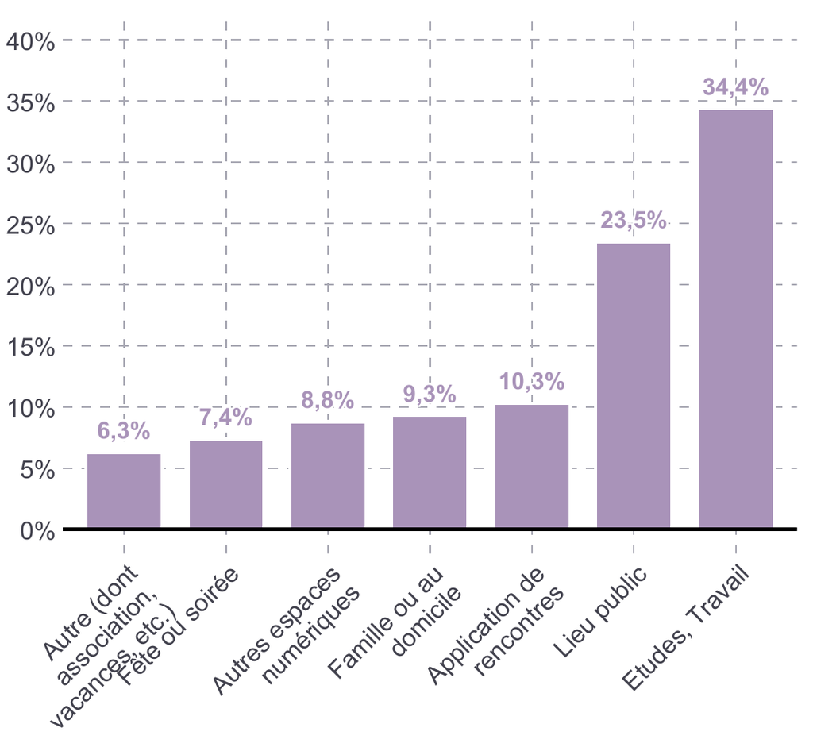

**Deux variables**

```r
ined_baton(
    donnees = dt_barre,
    var_y = "Valeur",
    var_x = "Lieu",
        var_couleur = "Modalites",

    etiquette = "non",
    var_x_ordre = "base",

    legende_position = c(0.25,0.75),
    titre_x = "Lieu de rencontre",

    y_min = 0,
    y_max = 50,
    y_intervalle = 10,
    y_pct = TRUE,

    var_x_angle = 90,
    ncarac_var_x = 20,
    ncarac_legende = 15,

    #Export
    export  = TRUE,
    fichier = "Sortie/barre_moyen",
    format = "moyen"
    )
```

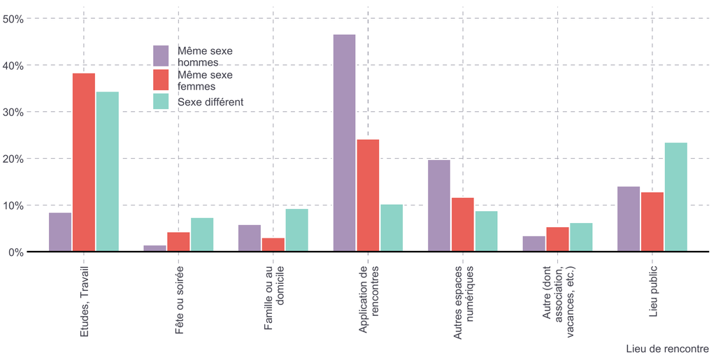

**Trois variables**

```r
ined_baton(
    donnees = dt_barre,
    var_y = "Valeur",
    var_x = "Modalites",
    var_couleur = "Lieu",
    var_facet = "Relation",
    facet_disposition = "ligne",

    palette = "oppose",

    etiquette = "max",
    etiquette_arrondi = 1,

    legende_position = "droite",

    legende_ncol = 1,

    titre_legende = "Type de couples :",

    y_pct = TRUE,
    y_max = 70,
    y_intervalle = 10,

    var_x_angle = 45,

    ncarac_titre = 50,
    ncarac_titre_x = 35,
    ncarac_var_x = 15,
    ncarac_legende = 20,
    ncarac_facet = 10,

    #Export
    export  = TRUE,
    fichier = "Sortie/barre_moyen",
    format = "moyen"
    )
```

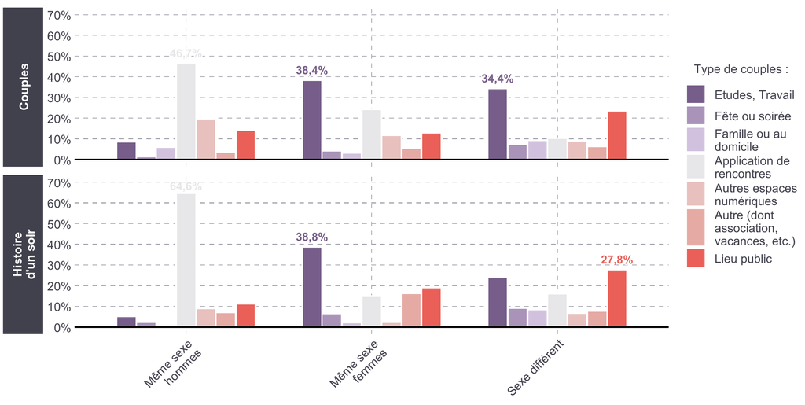

# Graphiques empilés

## Fonction ined_empile()

### Données & Variables

- **donnees** : (obligatoire) Données à utiliser dans le graphique. Il s’agit de données agrégées dans le même format que les données de la section “Exemple”, ci-dessous.

Pour tous les arguments ci-dessous, il est possible d’indiquer soit le nom (entre guillemets), soit la position (numéro de colonne) des variables.

- **var_y** : (obligatoire) Variable numérique des valeurs. Il s’agit des quantités à représenter sur le graphique.
- **var_x** : (obligatoire) Variable à afficher sur l’axe X.
- **var_couleur** : Variable catégorielle qui détermine la couleur des barres.
- **var_facet** : Variable catégorielle qui crée des graphiques côte-à-côte pour chaque modalité d’une variable.

### Ordre des modalités et couleurs

- **facet_disposition** : position des graphiques en facettes (avec l’argument : *var_facet*), sur des lignes, sur des colonnes, ou en carré/mosaïque.
  - *“colonne* : En colonne, l’un à côté de l’autre.
  - *“ligne”* : En ligne, l’un au dessus de l’autre.
  - *“carre”* : Disposition automatique, en carré.
- **barre_orient** : Orientation des barres empilées.
  - *“horizontal”* : (défaut) barres horizontales
  - *“vertical”* : barres verticales
- **var_x_ordre** : Ordre des modalités de la variable X.
  - *“base”* : Ordre présent dans les données renseignées dans *donnees*.
  - *“inverse”* : Inverse de l’ordre de la base.
  - *“alpha”* : Ordre alphabétique.
  - *“croissant”* : Modalités ordonnées dans l’ordre croissant des effectifs de chaque modalité de *var_x*.
- **var_couleur_ordre** : Ordre des modalités de la variable de couleurs, créée avec *var_couleur* (dans la légende et dans l’ordre des barres).
  - *“base”* : Ordre présent dans les données renseignées dans *donnees*.
  - *“inverse”* : Inverse de l’ordre de la base.
  - *“alpha”* : Ordre alphabétique.
- **palette** : Choix de la palette de couleurs
  - *“categorie”* : (défaut) Une palette avec 9 couleurs pour des variables catégorielles, sans hiérarchie.
  - *“genre”* : Une palette avec 4 couleurs à utiliser pour visualiser les variables de genre
  - *“orange”* : Une palette avec un dégradé de 7 orange pour les variables ordinales
  - *“violet”* : Une palette avec un dégradé de 7 violet pour les variables ordinales
  - *“oppose”* : Une palette qui va du violet au orange, et qui s’adapte au nombre de modalité (jusqu’à 8)

**NoteInverser la palette**

Toutes les palettes peuvent être inversées en ajoutant le suffixe “_inv”, par exemple : “oppose_inv” ou “categorie_inv”.

### Etiquettes

- **etiquette** : Afficher une étiquette de valeur sur les barres.
  - *“oui”* : Affiche toutes les étiquettes
  - *“max”* : Affiche uniquement la valeur maximale
  - *“non”* : Pas d’étiquettes
- **etiquette_min** : Valeur numérique minimale à partir de laquelle afficher les étiquettes.
- **etiquette_arrondi** : Nombre de chiffre après la virgule pour les étiquettes.

### Légende

- **legende_position** : Position de la légende.
  - *A droite* : “right”, “droite”
  - *En bas* : “bottom”, “bas”
  - *A gauche* : “left”, “gauche”
  - *En haut* : “top”, “haut”
  - *Dans le graphique* : coordonnées de la position sur le graphique.  
    → Exemple : c(0.75, 0.33), pour placer le coin supérieur gauche de la légende en X = 0.75 et Y = 0.33
- **legende_ncol** : Nombre de colonnes sur lesquelles la légende est répartie.
- **legende_ordre** : “ligne” ou “colonne” ; Si la légende est disposée sur plusieurs colonnes, permet de changer l’ordre de lecture des modalités, pour les placer en ligne ou en colonne.

### Modification axes X et Y

**Axe Y :**

- **y_max** : Valeur maximale à afficher de l’axe Y
- **y_intervalle** : Intervalle entre les graduations de l’axe Y
- **y_pct** : TRUE / FALSE ; Si TRUE : l’échelle de l’axe Y affiche le symbole “%”

**Axe X :**

- **var_x_angle** : Angle des modalités de l’axe X.

### Textes & Titres

**Titres :**

- **titre** : Titre du graphique (entre guillemets)
- **titre_x** : Titre de l’axe X (entre guillemets)
- **titre_y** : Titre de l’axe Y (entre guillemets)
- **titre_legende** : Titre de la légende (entre guillemets)

**Nombre de caractères avant un saut de ligne :**

Si besoin en cas de textes trop longs.

- **ncarac_titre** : Pour le titre
- **ncarac_titre_x** : Pour le titre de l’axe X
- **ncarac_titre_y** : Pour le titre de l’axe Y
- **ncarac_titre_legende** : Pour le titre de la légende
- **ncarac_var_x** : Pour les modalités de l’axe X
- **ncarac_legende** : Pour les modalités de la légende
- **ncarac_facet** : Pour les modalités des facettes.

### Export

- **export** : TRUE ou FALSE ; si TRUE : enregistre l’image au format .pdf et .svg, si FALSE : affiche uniquement le graphique
- **fichier** : chemin et nom du fichier à enregistrer, par défaut “graphique”.
- **format** : “petit”, “moyen”, “grand”, définit le format du graphique.

## Exemple

### Charger la fonction

```r
source("Programme/fonction_empile.R")
# ou depuis GitHub (dernière version)
source("https://raw.githubusercontent.com/arnomuller/Fonction_R/refs/heads/main/inedits/Programme/fonction_empile.R")
```

## Fonctionnement

```r
library(openxlsx)
dt_pct = read.xlsx("Data/data_ex_pct.xlsx", sheet = 1)
```

| Valeur | Modalites |
| --- | --- |
| 58,79 | C'était le bon moment |
| 17,76 | N'y pensait pas beaucoup |
| 15,14 | Aurait préféré plus tôt |
| 7,38 | Aurait préféré plus tard |
| 0,68 | N'en avait pas du tout envie |
| 0,25 | A été forcé·e |

```r
library(openxlsx)
dt_pct = read.xlsx("Data/data_ex_pct.xlsx",
                     sheet = 2)
```

| Valeur | Ages | Modalites |
| --- | --- | --- |
| 49,79 | Avant 16 ans | C'était le bon moment |
| 64,38 | 16 ans | C'était le bon moment |
| 70,90 | 17 ans | C'était le bon moment |
| 72,23 | 18 ans | C'était le bon moment |
| 73,88 | 19 ans ou après | C'était le bon moment |
| 9,80 | Avant 16 ans | N'y pensait pas beaucoup |
| 7,75 | 16 ans | N'y pensait pas beaucoup |
| 9,90 | 17 ans | N'y pensait pas beaucoup |
| 9,74 | 18 ans | N'y pensait pas beaucoup |
| 9,45 | 19 ans ou après | N'y pensait pas beaucoup |
| 1,56 | Avant 16 ans | Aurait préféré plus tôt |
| 0,65 | 16 ans | Aurait préféré plus tôt |
| 0,40 | 17 ans | Aurait préféré plus tôt |
| 1,17 | 18 ans | Aurait préféré plus tôt |
| 3,52 | 19 ans ou après | Aurait préféré plus tôt |
| 28,61 | Avant 16 ans | Aurait préféré plus tard |
| 24,49 | 16 ans | Aurait préféré plus tard |
| 15,51 | 17 ans | Aurait préféré plus tard |
| 14,16 | 18 ans | Aurait préféré plus tard |
| 9,67 | 19 ans ou après | Aurait préféré plus tard |
| 2,74 | Avant 16 ans | N'en avait pas du tout envie |
| 0,98 | 16 ans | N'en avait pas du tout envie |
| 1,65 | 17 ans | N'en avait pas du tout envie |
| 1,05 | 18 ans | N'en avait pas du tout envie |
| 1,51 | 19 ans ou après | N'en avait pas du tout envie |
| 7,50 | Avant 16 ans | A été forcé·e |
| 1,75 | 16 ans | A été forcé·e |
| 1,64 | 17 ans | A été forcé·e |
| 1,65 | 18 ans | A été forcé·e |
| 1,97 | 19 ans ou après | A été forcé·e |

```r
library(openxlsx)
dt_pct = read.xlsx("Data/data_ex_pct.xlsx",
                     sheet = 3)
```

| Valeur | Ages | Modalites | Genre |
| --- | --- | --- | --- |
| 49,79 | Avant 16 ans | C'était le bon moment | Femmes |
| 64,38 | 16 ans | C'était le bon moment | Femmes |
| 70,90 | 17 ans | C'était le bon moment | Femmes |
| 72,23 | 18 ans | C'était le bon moment | Femmes |
| 73,88 | 19 ans ou après | C'était le bon moment | Femmes |
| 9,80 | Avant 16 ans | N'y pensait pas beaucoup | Femmes |
| 7,75 | 16 ans | N'y pensait pas beaucoup | Femmes |
| 9,90 | 17 ans | N'y pensait pas beaucoup | Femmes |
| 9,74 | 18 ans | N'y pensait pas beaucoup | Femmes |
| 9,45 | 19 ans ou après | N'y pensait pas beaucoup | Femmes |
| 1,56 | Avant 16 ans | Aurait préféré plus tôt | Femmes |
| 0,65 | 16 ans | Aurait préféré plus tôt | Femmes |
| 0,40 | 17 ans | Aurait préféré plus tôt | Femmes |
| 1,17 | 18 ans | Aurait préféré plus tôt | Femmes |
| 3,52 | 19 ans ou après | Aurait préféré plus tôt | Femmes |
| 28,61 | Avant 16 ans | Aurait préféré plus tard | Femmes |
| 24,49 | 16 ans | Aurait préféré plus tard | Femmes |
| 15,51 | 17 ans | Aurait préféré plus tard | Femmes |
| 14,16 | 18 ans | Aurait préféré plus tard | Femmes |
| 9,67 | 19 ans ou après | Aurait préféré plus tard | Femmes |
| 2,74 | Avant 16 ans | N'en avait pas du tout envie | Femmes |
| 0,98 | 16 ans | N'en avait pas du tout envie | Femmes |
| 1,65 | 17 ans | N'en avait pas du tout envie | Femmes |
| 1,05 | 18 ans | N'en avait pas du tout envie | Femmes |
| 1,51 | 19 ans ou après | N'en avait pas du tout envie | Femmes |
| 7,50 | Avant 16 ans | A été forcé·e | Femmes |
| 1,75 | 16 ans | A été forcé·e | Femmes |
| 1,64 | 17 ans | A été forcé·e | Femmes |
| 1,65 | 18 ans | A été forcé·e | Femmes |
| 1,97 | 19 ans ou après | A été forcé·e | Femmes |
| 56,64 | Avant 16 ans | C'était le bon moment | Hommes |
| 65,10 | 16 ans | C'était le bon moment | Hommes |
| 69,24 | 17 ans | C'était le bon moment | Hommes |
| 63,87 | 18 ans | C'était le bon moment | Hommes |
| 58,79 | 19 ans ou après | C'était le bon moment | Hommes |
| 20,56 | Avant 16 ans | N'y pensait pas beaucoup | Hommes |
| 16,67 | 16 ans | N'y pensait pas beaucoup | Hommes |
| 14,53 | 17 ans | N'y pensait pas beaucoup | Hommes |
| 14,11 | 18 ans | N'y pensait pas beaucoup | Hommes |
| 17,76 | 19 ans ou après | N'y pensait pas beaucoup | Hommes |
| 3,32 | Avant 16 ans | Aurait préféré plus tôt | Hommes |
| 2,79 | 16 ans | Aurait préféré plus tôt | Hommes |
| 5,15 | 17 ans | Aurait préféré plus tôt | Hommes |
| 11,00 | 18 ans | Aurait préféré plus tôt | Hommes |
| 15,14 | 19 ans ou après | Aurait préféré plus tôt | Hommes |
| 18,46 | Avant 16 ans | Aurait préféré plus tard | Hommes |
| 15,04 | 16 ans | Aurait préféré plus tard | Hommes |
| 10,23 | 17 ans | Aurait préféré plus tard | Hommes |
| 10,14 | 18 ans | Aurait préféré plus tard | Hommes |
| 7,38 | 19 ans ou après | Aurait préféré plus tard | Hommes |
| 0,59 | Avant 16 ans | N'en avait pas du tout envie | Hommes |
| 0,38 | 16 ans | N'en avait pas du tout envie | Hommes |
| 0,48 | 17 ans | N'en avait pas du tout envie | Hommes |
| 0,82 | 18 ans | N'en avait pas du tout envie | Hommes |
| 0,68 | 19 ans ou après | N'en avait pas du tout envie | Hommes |
| 0,44 | Avant 16 ans | A été forcé·e | Hommes |
| 0,02 | 16 ans | A été forcé·e | Hommes |
| 0,37 | 17 ans | A été forcé·e | Hommes |
| 0,06 | 18 ans | A été forcé·e | Hommes |
| 0,25 | 19 ans ou après | A été forcé·e | Hommes |

**Une variable**

```r
ined_empile(
  donnees = dt_pct,
  var_y = "Valeur",
  var_x = "Modalites",
  etiquette = "oui",
  etiquette_arrondi = 2,
  var_x_ordre = "croissant",
  y_max = 70,
  y_intervalle = 5,
  y_pct = TRUE,
  var_x_angle = 45,
  ncarac_var_x = 20,

  #Export
  export  = TRUE,
  fichier = "Sortie/empile_petit",
  format = "petit"

)
```

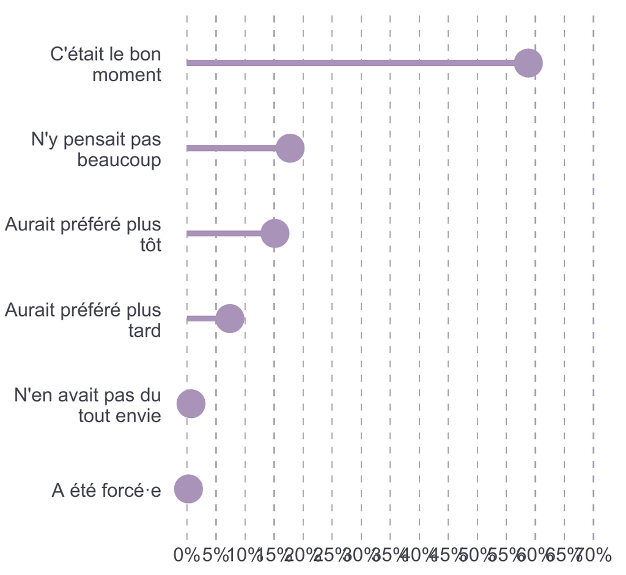

**Deux variables**

```r
ined_empile(
  donnees = dt_pct,
  var_y = "Valeur",
  var_x = "Ages",
  var_couleur = "Modalites",
  var_x_ordre = "inverse",
  var_couleur_ordre = "inverse",

  barre_orient = "vertical",
  palette = "violet",

  etiquette = "oui",
  etiquette_min = 5,

  legende_position = "droite",
  legende_ncol = 1,

  y_max = 100,
  y_intervalle = 10,
  y_pct = TRUE,

  ncarac_var_x = 20,
  ncarac_legende = 15,

  #Export
  export  = TRUE,
  fichier = "Sortie/empile_moyen",
  format = "moyen"

)
```

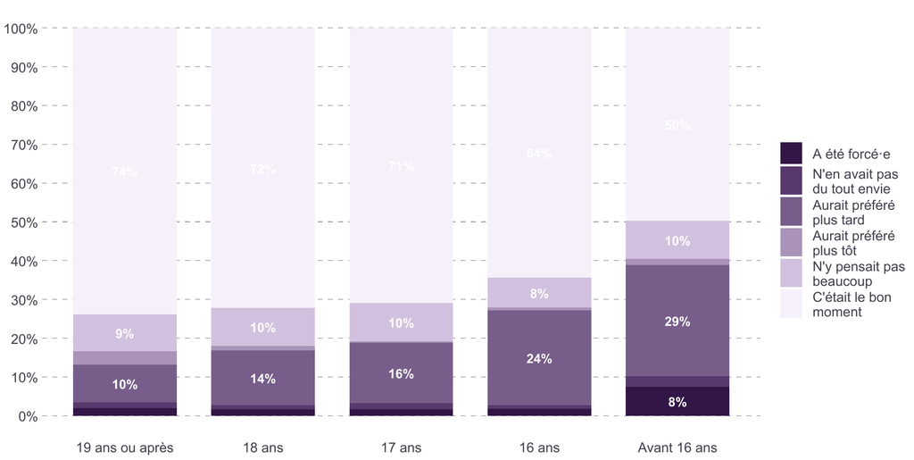

**Trois variables**

```r
ined_empile(
  donnees = dt_pct,
  var_y = 1,
  var_x = 2,
  var_couleur = 3,
  var_facet = 4,
  facet_disposition = "lignes",
  barre_orient = "horizontal",

  etiquette = "oui",
  etiquette_min = 10,
  etiquette_arrondi = 1,

  var_x_ordre = "inverse",
  var_couleur_ordre = "inverse",
  palette = "oppose",

  legende_position = "bas",
  legende_ncol = 3,
  legende_ordre = "colonne",

  titre = "",
  titre_x = "",
  titre_y = "",
  titre_legende = "",

  y_max = NULL,
  y_intervalle = 20,
  y_pct = F,


  var_x_angle = 45,
  bg_color = "#FFF",

  ncarac_titre = 50,
  ncarac_titre_x = 35,
  ncarac_titre_y = 35,
  ncarac_titre_legende = 30,
  ncarac_var_x = 25,
  ncarac_legende = 40,
  ncarac_facet = 40,

  #Export
  export  = TRUE,
  fichier = "Sortie/empile_moyen",
  format = "moyen"

)
```

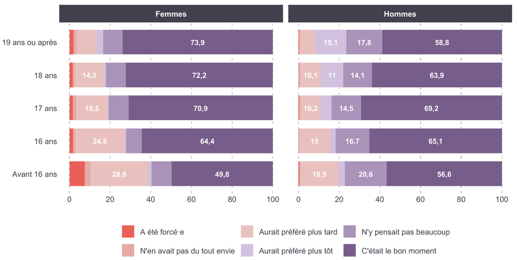

# Graphiques courbes

## Fonction ined_courbe()

### Données & Variables

- **donnees** : (obligatoire) Données à utiliser dans le graphique. Il s’agit de données agrégées dans le même format que les données de la section “Exemple”, ci-dessous.

Pour tous les arguments ci-dessous, il est possible d’indiquer soit le nom (entre guillemets), soit la position (numéro de colonne) des variables.

- **var_y** : (obligatoire) Variable numérique des valeurs. Il s’agit des quantités à représenter sur le graphique.
- **var_x** : (obligatoire) Variable à afficher sur l’axe X.
- **var_couleur** : Variable catégorielle qui détermine la couleur des courbes
- **var_typeligne** : Variable catégorielle qui détermine le style des courbes (trait plein, pointillé, etc.)
- **var_facet** : Variable catégorielle qui crée des graphiques côte-à-côte pour chaque modalité d’une variable.
- **type_graph** : Type de graphiques :
  - *“courbes”* : faire apparaître uniquement les courbes
  - *“courbes+points”* : faire apparaître des courbes et des points
  - *“points”* : faire apparaître uniquement les points

### Ordre des modalités et couleurs

- **facet_disposition** : position des graphiques en facettes (avec l’argument : *var_facet*), sur des lignes, sur des colonnes, ou en carré/mosaïque.
  - *“colonne* : En colonne, l’un à côté de l’autre.
  - *“ligne”* : En ligne, l’un au dessus de l’autre.
  - *“carre”* : Disposition automatique, en carré.
- **barre_orient** : Orientation des barres empilées.
  - *“horizontal”* : (défaut) barres horizontales
  - *“vertical”* : barres verticales
- **var_x_ordre** : Ordre des modalités de la variable X.
  - *“base”* : Ordre présent dans les données renseignées dans *donnees*.
  - *“inverse”* : Inverse de l’ordre de la base.
  - *“alpha”* : Ordre alphabétique.
  - *“croissant”* : Modalités ordonnées dans l’ordre croissant des effectifs de chaque modalité de *var_x*.
  - *“decroissant”* : Modalités ordonnées dans l’ordre décroissant des effectifs de chaque modalité de *var_x*.
  - *“numerique”* : Pour les cas où les modalités de *var_x* sont numériques.
- **var_couleur_ordre** : Ordre des modalités de la variable de couleurs, créée avec *var_couleur* (dans la légende).
  - *“base”* : Ordre présent dans les données renseignées dans *donnees*.
  - *“inverse”* : Inverse de l’ordre de la base.
  - *“alpha”* : Ordre alphabétique.
- **var_typeligne_ordre** : Ordre des modalités de la variable de type de ligne, créée avec *var_typeligne* (dans la légende).
  - *“base”* : Ordre présent dans les données renseignées dans *donnees*.
  - *“inverse”* : Inverse de l’ordre de la base.
  - *“alpha”* : Ordre alphabétique.
- **lisser_courbe** : TRUE/FALSE : pour afficher des courbes lissées.
- **palette** : Choix de la palette de couleurs
  - *“categorie”* : (défaut) Une palette avec 9 couleurs pour des variables catégorielles, sans hiérarchie.
  - *“genre”* : Une palette avec 4 couleurs à utiliser pour visualiser les variables de genre
  - *“orange”* : Une palette avec un dégradé de 7 orange pour les variables ordinales
  - *“violet”* : Une palette avec un dégradé de 7 violet pour les variables ordinales
  - *“oppose”* : Une palette qui va du violet au orange, et qui s’adapte au nombre de modalité (jusqu’à 8)

**NoteInverser la palette**

Toutes les palettes peuvent être inversées en ajoutant le suffixe “_inv”, par exemple : “oppose_inv” ou “categorie_inv”.

- **style_courbe** : Un vecteur avec le type de trait à afficher pour chaque modalité de *var_typeligne*  
  → Exemple : c(“solid”, “dotted”,“dashed”), pour un trait plein, suivi de pointillé, suivi de tirets (voir les options de R)

### Etiquettes des points

- **etiquette** : Afficher une étiquette de valeur sur les barres.
  - *“oui”* : Affiche toutes les étiquettes
  - *“max”* : Affiche uniquement les valeurs maximales
  - *“min”* : Affiche uniquement les valeurs minimales
  - *“non”* : Pas d’étiquettes
- **etiquette_min** : Valeur numérique minimale à partir de laquelle afficher les étiquettes.
- **etiquette_arrondi** : Nombre de chiffre après la virgule pour les étiquettes.

### Légende

- **legende_position** : Position de la légende.
  - *Dans la courbe* : “courbe”
  - *A droite* : “right”, “droite”
  - *En bas* : “bottom”, “bas”
  - *A gauche* : “left”, “gauche”
  - *En haut* : “top”, “haut”
  - *Dans le graphique* : coordonnées de la position sur le graphique.  
    → Exemple : c(0.75, 0.33), pour placer le coin supérieur gauche de la légende en X = 0.75 et Y = 0.33
- **legende_ncol_couleur** : Nombre de colonnes sur lesquelles la légende de la couleur est répartie.
- **legende_ncol_ligne** : Nombre de colonnes sur lesquelles la légende du type de ligne est répartie.
- **courbe_etiquette_position** : Position de l’étiquette à l’intérieur de la courbe (si légende = “courbe”) :
  - *“ymax”* : Place le nom de la courbe à son maximum sur l’axe Y
  - *“ymid”* : Place le nom de la courbe à une position centrale sur l’axe Y
  - *“ymin”* : Place le nom de la courbe à son minimum sur l’axe Y
  - *“auto”* : Place automatiquement le nom de la courbe
  - Une valeur numérique entre 0 et 1 : Place le nom de la courbe à l’endroit voulu entre son début (0) et sa fin (1)
- **courbe_etiquette_lisser_intensite** : Un gradient de 0 à 100 qui lisse l’étiquette dans la courbe (si légende = “courbe”)

### Modification axes X et Y

**Axe Y :**

- **y_min** : Valeur minimale à afficher de l’axe Y
- **y_max** : Valeur maximale à afficher de l’axe Y
- **y_intervalle** : Intervalle entre les graduations de l’axe Y
- **y_pct** : TRUE / FALSE ; Si TRUE : l’échelle de l’axe Y affiche le symbole “%”

**Axe X :**

- **x_intervalle** : Intervalle entre les graduations de l’axe X (si *var_x_ordre* = “numerique”)
- **var_x_angle** : Angle des modalités de l’axe X.

### Textes & Titres

**Titres :**

- **titre** : Titre du graphique (entre guillemets)
- **titre_x** : Titre de l’axe X (entre guillemets)
- **titre_y** : Titre de l’axe Y (entre guillemets)
- **titre_legende_couleur** : Titre de la légende de la variable de couleurs (entre guillemets)
- **titre_legende_ligne** : Titre de la légende de la variable de style de ligne (entre guillemets)

**Nombre de caractères avant un saut de ligne :**

Si besoin en cas de textes trop longs.

- **ncarac_titre** : Pour le titre
- **ncarac_titre_x** : Pour le titre de l’axe X
- **ncarac_titre_y** : Pour le titre de l’axe Y
- **ncarac_titre_legende_couleur** : Pour le titre de la légende de la variable de couleur
- **ncarac_titre_legende_ligne** : Pour le titre de la légende de la variable de style de ligne
- **ncarac_var_x** : Pour les modalités de l’axe X
- **ncarac_legende_couleur** : Pour les modalités de la variable de couleurs
- **ncarac_legende_ligne** : Pour les modalités de la variable de couleurs
- **ncarac_facet** : Pour les modalités des facettes.

### Export

- **export** : TRUE ou FALSE ; si TRUE : enregistre l’image au format .pdf et .svg, si FALSE : affiche uniquement le graphique
- **fichier** : chemin et nom du fichier à enregistrer, par défaut “graphique”.
- **format** : “petit”, “moyen”, “grand”, définit le format du graphique.

## Exemple

### Charger la fonction

```r
source("Programme/fonction_courbe.R")
# ou depuis GitHub (dernière version)
source("https://raw.githubusercontent.com/arnomuller/Fonction_R/refs/heads/main/inedits/Programme/fonction_courbe.R")
```

## Fonctionnement

```r
library(openxlsx)
dt_courbe = read.xlsx("Data/data_ex_courbe.xlsx", sheet = 1)
```

| Valeur | Ages |
| --- | --- |
| 1,09 | 7 |
| 1,53 | 8 |
| 2,54 | 9 |
| 3,58 | 10 |
| 6,95 | 11 |
| 11,24 | 12 |
| 21,18 | 13 |
| 33,67 | 14 |
| 48,18 | 15 |
| 61,19 | 16 |
| 71,88 | 17 |
| 79,47 | 18 |

```r
library(openxlsx)
dt_courbe = read.xlsx("Data/data_ex_courbe.xlsx",
                     sheet = 2)
```

| Valeur | Ages | Genre |
| --- | --- | --- |
| 1,09 | 7 | Hommes |
| 1,53 | 8 | Hommes |
| 2,54 | 9 | Hommes |
| 3,58 | 10 | Hommes |
| 6,95 | 11 | Hommes |
| 11,24 | 12 | Hommes |
| 21,18 | 13 | Hommes |
| 33,67 | 14 | Hommes |
| 48,18 | 15 | Hommes |
| 61,19 | 16 | Hommes |
| 71,88 | 17 | Hommes |
| 79,47 | 18 | Hommes |
| 0,45 | 7 | Femmes |
| 0,56 | 8 | Femmes |
| 1,22 | 9 | Femmes |
| 1,46 | 10 | Femmes |
| 2,47 | 11 | Femmes |
| 4,51 | 12 | Femmes |
| 10,44 | 13 | Femmes |
| 19,96 | 14 | Femmes |
| 35,95 | 15 | Femmes |
| 52,80 | 16 | Femmes |
| 68,00 | 17 | Femmes |
| 77,46 | 18 | Femmes |

```r
library(openxlsx)
dt_courbe = read.xlsx("Data/data_ex_courbe.xlsx",
                     sheet = 3)
```

| Valeur | Ages | Genre | Groupe |
| --- | --- | --- | --- |
| 1,09 | 7 | Hommes | Premier baiser |
| 1,53 | 8 | Hommes | Premier baiser |
| 2,54 | 9 | Hommes | Premier baiser |
| 3,58 | 10 | Hommes | Premier baiser |
| 6,95 | 11 | Hommes | Premier baiser |
| 11,24 | 12 | Hommes | Premier baiser |
| 21,18 | 13 | Hommes | Premier baiser |
| 33,67 | 14 | Hommes | Premier baiser |
| 48,18 | 15 | Hommes | Premier baiser |
| 61,19 | 16 | Hommes | Premier baiser |
| 71,88 | 17 | Hommes | Premier baiser |
| 79,47 | 18 | Hommes | Premier baiser |
| 0,45 | 7 | Femmes | Premier baiser |
| 0,56 | 8 | Femmes | Premier baiser |
| 1,22 | 9 | Femmes | Premier baiser |
| 1,46 | 10 | Femmes | Premier baiser |
| 2,47 | 11 | Femmes | Premier baiser |
| 4,51 | 12 | Femmes | Premier baiser |
| 10,44 | 13 | Femmes | Premier baiser |
| 19,96 | 14 | Femmes | Premier baiser |
| 35,95 | 15 | Femmes | Premier baiser |
| 52,80 | 16 | Femmes | Premier baiser |
| 68,00 | 17 | Femmes | Premier baiser |
| 77,46 | 18 | Femmes | Premier baiser |
| 0,06 | 7 | Hommes | Premières pratiques sexuelles |
| 0,26 | 8 | Hommes | Premières pratiques sexuelles |
| 0,37 | 9 | Hommes | Premières pratiques sexuelles |
| 0,55 | 10 | Hommes | Premières pratiques sexuelles |
| 0,65 | 11 | Hommes | Premières pratiques sexuelles |
| 1,10 | 12 | Hommes | Premières pratiques sexuelles |
| 2,06 | 13 | Hommes | Premières pratiques sexuelles |
| 5,44 | 14 | Hommes | Premières pratiques sexuelles |
| 13,97 | 15 | Hommes | Premières pratiques sexuelles |
| 25,03 | 16 | Hommes | Premières pratiques sexuelles |
| 39,63 | 17 | Hommes | Premières pratiques sexuelles |
| 56,18 | 18 | Hommes | Premières pratiques sexuelles |
| 0,12 | 7 | Femmes | Premières pratiques sexuelles |
| 0,18 | 8 | Femmes | Premières pratiques sexuelles |
| 0,29 | 9 | Femmes | Premières pratiques sexuelles |
| 0,44 | 10 | Femmes | Premières pratiques sexuelles |
| 0,44 | 11 | Femmes | Premières pratiques sexuelles |
| 0,51 | 12 | Femmes | Premières pratiques sexuelles |
| 1,10 | 13 | Femmes | Premières pratiques sexuelles |
| 2,35 | 14 | Femmes | Premières pratiques sexuelles |
| 8,70 | 15 | Femmes | Premières pratiques sexuelles |
| 20,65 | 16 | Femmes | Premières pratiques sexuelles |
| 36,58 | 17 | Femmes | Premières pratiques sexuelles |
| 53,99 | 18 | Femmes | Premières pratiques sexuelles |

**Une variable**

```r
ined_courbe(
  donnee = dt_courbe,
  var_y = "Valeur",
  var_x = "Ages",
  var_x_ordre = "numerique",

  palette      = "orange",

  y_pct = T,
  y_min = 0,
  y_max = 100,
  y_intervalle = 20,
  x_intervalle = 1,

  lisser_courbe = T,

  titre_x = "Âges au premier rapport sexuel",
  ncarac_titre_x = 15,

  #Export
  export  = TRUE,
  fichier = "Sortie/courbe_petit",
  format = "petit"

)
```

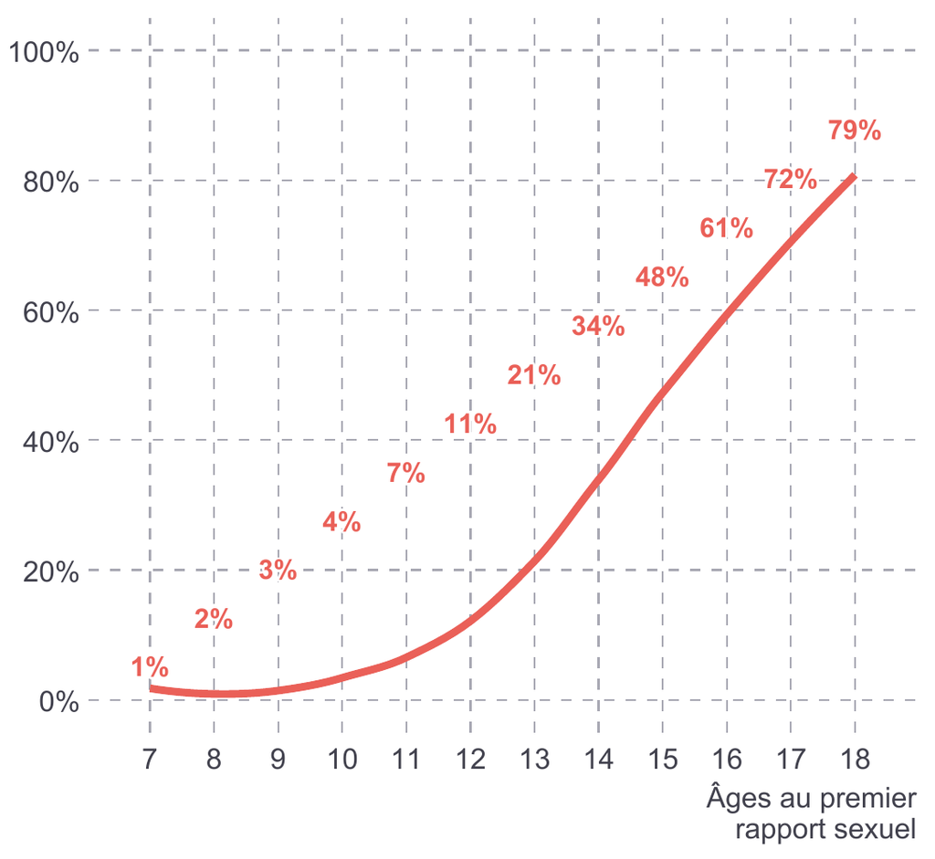

**Deux variables**

```r
ined_courbe(
  donnees = dt_courbe,
  var_y = "Valeur",
  var_x = "Ages",
  var_couleur = "Genre",
  type_graph = "points",

  var_x_ordre = "numerique",
  var_couleur_ordre = "base",

  etiquette = "max",

  y_pct = F,
  lisser_courbe = F,

  legende_position = "bas",
  legende_ncol_couleur = 2,

  y_min = NULL,
  y_max = 100,
  y_intervalle = 20,
  x_intervalle = 1,

  titre_x = "Âges au premier rapport sexuel",
  ncarac_titre_x = 15,

  #Export
  export  = TRUE,
  fichier = "Sortie/courbe_petit",
  format = "petit"

)
```

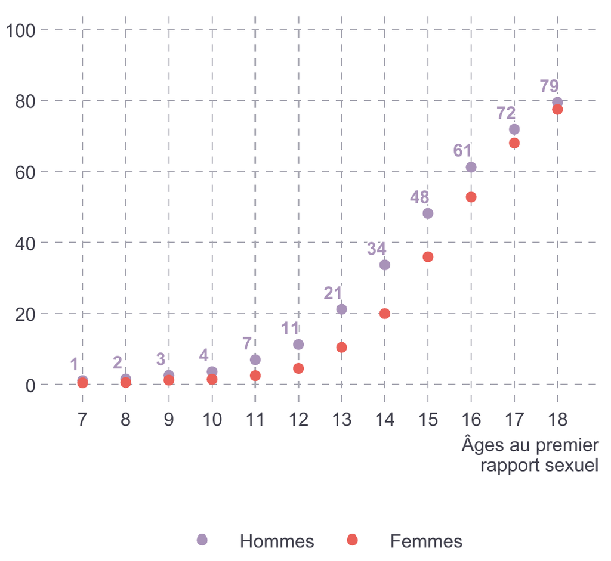

**Trois variables**

```r
ined_courbe(
  donnees = dt_courbe,
  var_y = "Valeur",
  var_x = "Ages",
  var_couleur = "Genre",
  var_typeligne = "Groupe",

  var_x_ordre = "numerique",
  x_intervalle = 2,

  palette      = "genre",
  style_courbe = c("longdash","solid"),

  y_pct = T,
  lisser_courbe = F,

  legende_position = "courbe",

  courbe_etiquette_position = "ymid",
  courbe_etiquette_lisser_intensite = 60,

  #Export
  export  = TRUE,
  fichier = "Sortie/courbe_moyen",
  format = "moyen"

)
```

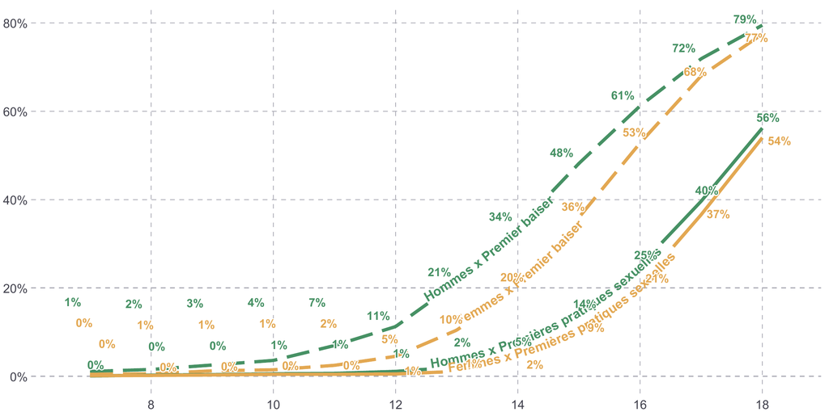

# Export des graphiques

**AvertissementAttention :**

L’export se fait directement depuis les fonctions de création de graphiques, la fonction `ined_export()` n’est a utiliser que pour exporter des graphiques que vous aurez modifiez dans R.

Pour cela, vous pouvez repartir de l’objet ggplot2 nommé *graph*, produit par les fonctions.

## Fonction ined_export()

### Arguments

- **graph :** (obligatoire) Un objet `ggplot2` issue d’une des fonctions de graphiques.
- **format :** taille du graphique.
  - “petit” : Pour un graphique de 9,23cm x 8cm
  - “moyen” : Pour un graphique de 18,97cm x 8cm
  - “grand” : Pour un graphique de 18,97cm x 20,33 cm
- **fichier :** une chaîne de caractère avec le chemin et le nom du fichier à sauvegarder. (ex : “Sortie/mongraph”)

### Exemple :

```r
ined_export(graph = graph,
            fichier = "Sortie/graphique",
            format = "moyen")
```

# Astuce générales en R

### Changer l’ordre des modalités

Vous pouvez utiliser l’addins `iorder()` du package *questionr*.  
Il s’agit d’une interface clique-bouton pour réordonner des modalités.

**AvertissementAttention :**

Pour que le nouvel ordre soit pris en compte, il faut réordonner les données avec la fonction `arrange()` après avoir ordonnée la variable/

```r
iorder(data$ma_variable)
data = arrange(data, ma_variable)
```

### Recoder une variable

Pour recoder une variable, vous pouvez utilser l’addins `irec()` du package *questionr*.  
Il s’agit d’une interface clique-bouton pour regrouper des modalités.

**Exemple :**

```r
questionr::irec()
```